# Module 5a: Non-linear Models

Econometrics II

Sannah Tijani (stijani@wu.ac.at)

Department of Economics, WU Vienna

Max Heinze (mheinze@wu.ac.at)

Department of Economics, WU Vienna

November 6, 2025

# Limited Dependent Variables

## Limited Dependent Variables

So far, we have mostly focused on **continuous** and **unconstrained** dependent variables, i.e. $Y \in \mathbb{R}$. However, many interesting variables are **limited** in some form.

- **Probabilities** range from 0 to 1
- **GDP** is a positive variable
- **Political orientation** is a categorical variable

Until now, we have treated these variables as approximately continuous, but this may cause severe issues.

A solution is to use specialised **limited dependent variable** (LDV) models.

## Example of LDVs

We can distinguish between **classification** and **regression**.

**Classification**: we speak of a classification model when the outcome is

- **Binary**: pass vs. fail, good vs. bad, sick vs. not, employed vs. unemployed
- **Categorical**: nationality, dog breeds, means of transport; or **ordinal**: good – okay – bad

**Regression**: we speak of a regression model when the outcome is

- **Censored, truncated, or positive**: wages, wealth, time
- **Count data**: number of votes, days since an accident

**Regression** is generally used in a broader sense and may encompass **classification**.

# Linear Probability Model

## Linear Probability Model

The **Linear Probability Model** is an **OLS regression** applied to a binary dependent variable $\boldsymbol{y} \in \{0,1\}$ as in:

$$Y =
\begin{cases}
1 & \text{with probability } p,\\[6pt]
0 & \text{with probability } 1 - p.
\end{cases}$$

The model:
$$\boldsymbol{y} = \boldsymbol{X}\beta + \boldsymbol{u}$$

The expected value of the **dependent variable** is equal to the probability $p$ that $\boldsymbol{y} = 1$.

Conditional on the regressor $\boldsymbol{X}$, we have:
$$\mathbb{E}[y \mid \boldsymbol{X}] = \mathbb{P}(y = 1 \mid \boldsymbol{X}) = \boldsymbol{X}\beta .$$

## Understanding the LPM

The **LPM** implies that $\beta_j$ gives us the **expected absolute change in probability** when $\boldsymbol{x}_j$ increases by 1. This linearity assumption can be a major limitation, as probabilities are naturally nonlinear.

$$\mathbb{P}(y \mid \boldsymbol{X}) = \beta_0 + \boldsymbol{x}_1\beta_1 + \dots + \boldsymbol{x}_k\beta_k$$

This linearity assumption can be a **major limitation** because:

- probabilities are naturally **nonlinear**
- **constant marginal effects** are unrealistic
- the linear prediction can exceed **0 or 1**

## Problems with the LPM

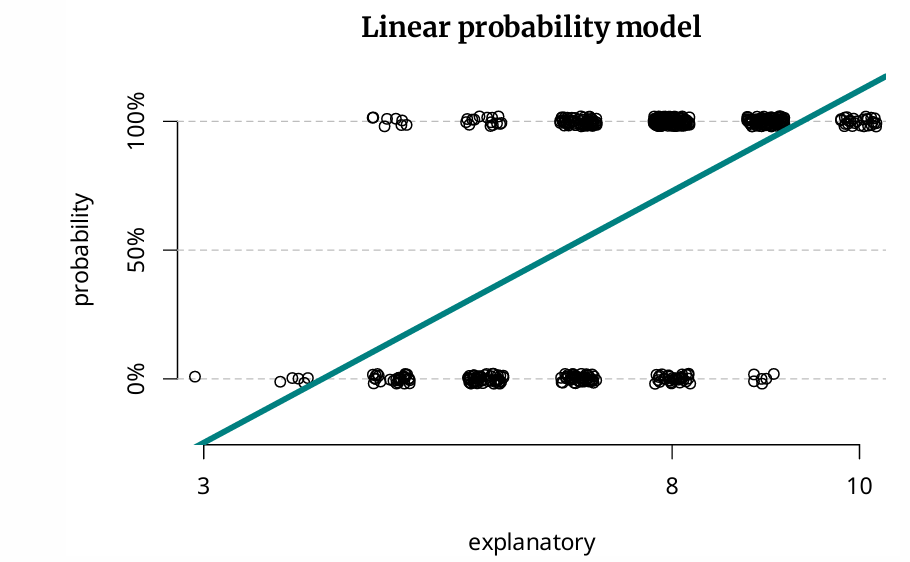

# Modeling Probabilities

## Modeling Probabilities

- When dealing with **probabilities**, the linearity assumption for $f$ may be too strong. We need another approach.
- We consider a function $G$ that satisfies $0 < G(z) < 1$.
- We can use $G$ to adapt our model to
  $$P(\boldsymbol{y} \mid \boldsymbol{X}) = G(\boldsymbol{X}\beta).$$
- In this way, we model a latent variable $\boldsymbol{z} = \boldsymbol{X}\beta$ using a linear model and link it to the dependent variable $\boldsymbol{y}$ via the **non-linear** function $G$, giving us $\boldsymbol{y} = G(\boldsymbol{z})$.
- The inverse function $G^{-1}(z)$ is called the **link function**.
- We can use different functional forms for $G$.

## Cumulative Distribution Function

The probability function $G(\boldsymbol{X}\beta)$ comes directly from the CDF of the error term in the latent variable model.

Start from $\boldsymbol{y}^* = \boldsymbol{X}\beta + u$, where:

- $\boldsymbol{y}^*$ is an unobserved continuous propensity
- $u$ is a random error term

We only observe:
$$y =
\begin{cases}
1 & \text{if } y^* > 0,\\[6pt]
0 & \text{otherwise}.
\end{cases}$$

It follows that the expected value of $y$ depends on the distribution of $u$:

$$\mathbb{P}(\boldsymbol{y} = 1 \mid \boldsymbol{X}) = \mathbb{P}(\boldsymbol{y}^* >0 | \boldsymbol{X}) = \mathbb{P}(u > -\boldsymbol{X} \beta)= \mathbb{P}(u < \boldsymbol{X} \beta) = F_u(\boldsymbol{X})\beta)$$

## The Logit Model

For the **logit model**, we use the cumulative distribution function (CDF) of a logistic variable — the logistic function — for $G$.

The link function is the **log-odds**: $\log \frac{p}{1-p}$.

$$G(\boldsymbol{z}=\frac{e^z}{e^z+1})$$

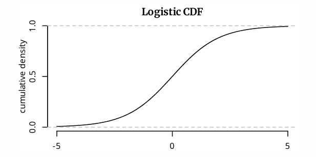

## The Probit Model

For the **probit model**, we use the CDF of a standard normal distribution, which gives us the probability that the standard normal variable $Z$ is smaller than $z$.

$$G(z) = \Phi(z) = \mathbb{P}(Z \le z), \quad \text{where } Z \sim \mathcal{N}(0,1).$$

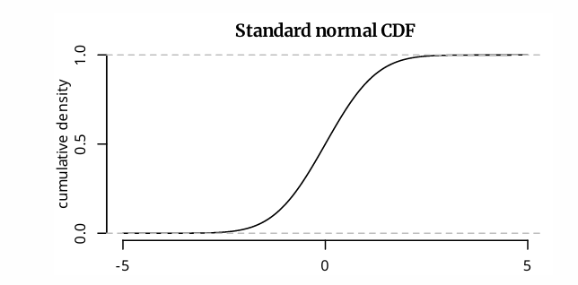

# Interpretation

## Interpretation

The interpretation of non-linear models such as logit and probit is not as straightforward as in linear models due to their non‐linearity.We can intrepret:

- sign of the coefficients, the direction of the expected change
- significance of coefficients

If $\beta_j >0$ we expect the probability to increase with $\boldsymbol{x_j}$.

However, we cannot interpret the magnitude of coefficients as magnitude of the effect of $\boldsymbol{X}$ on $\boldsymbol{y}$. Instead it captures the effects of $\boldsymbol{X}$ on the latent $\boldsymbol{z}$, which we rarely care about.

## Partial effects

The problem with interpreting coefficients is that the partial effects of $x_j$ are affected by all  
other variables. Assume $x_1$ is a dummy. Then:

$$\mathbb{P}(y \mid x_1 = 1, x_2, \ldots ) = G(\beta_0 + \beta_1 + x_2\beta_2 + \ldots)$$

$$\mathbb{P}(y \mid x_1 = 0, x_2, \ldots ) = G(\beta_0 + x_2\beta_2 + \ldots)$$

The change depends on the level of $x_2$ and other variables.

## Partial effects (2)

We can use **summary measures** to help interpret partial effects in non-linear models.

- **Partial effect at the average**: the partial effect at the average evaluates the effect when the **explanatory variables are at their mean**.

$$g(\,\bar{X}\,\hat{\beta}\,)\,\hat{\beta}_j$$

- **Average partial effect**: we calculate the **partial effect for each observation** and then take the average.

$$\frac{1}{N} \sum_{j=1}^{N} G(X\hat{\beta}) \, \hat{\beta}_j$$

# Inference

## Testing

To test the significance of single coefficients, we can use $t$ values.

For multiple coefficients we can use the **likelihood ratio** test

$$LR = 2(\text{log } \mathcal{L}_u - \text{log } \mathcal{L}_r)$$

We compare the likelihood of the **unrestricted** ($\mathcal{L}_u$) and **restricted** ($\mathcal{L}_r$) models, where the models are required to be nested (the complex model nests the simpler one).

**Likelihood**: The likelihood function is the joint probability of the observed data, viewed as a function of the parameters.

## Comparing Models

We can compare model specifications using

- $R^2$, the proportion of **explained variance**, for non-linear models there are various pseudo $R^2$ measures,
- the **likelihood**, $\mathcal{L}$, of a given model,
- **information criteria** (IC), which rewards model fit but penalizes model complexity

Many measures of model fit always increase with complexity — IC prefer **parsimony**.

**Akaike** information criterion
$$\text{AIC} = 2K - 2 \log \hat{\mathcal{L}}$$

**Bayesian (or Schwarz)** information criterion:
$$\text{BIC} = K \log N - 2 \log \hat{\mathcal{L}}$$

## Other Probability Models

Probabilities are not the only limited dependent variables, and there is a range of other **specialised models**. This includes the:

- **Poisson model** for count variables,  
  e.g. $Y \in \{0,1,2,\ldots\}$ for votes
- **Tobit model** for censored variables,  
  e.g. $Y > 0$ for forest loss
- **Heckit model** for non-random samples,  
  which uses the Heckman correction by modeling the sampling probability
- **Multinomial probit/logit model** for categorical variables,  
  e.g. $Y \in \{\text{agree}, \text{disagree}, \text{unsure}\}$

# Count Data

## Count Data

Count data take **non-negative integer values** $(0,1,2,\ldots)$ and often include a substantial number of zero outcomes (“zero-inflated”).

To build a model for this kind of data, we could:

- think of a **latent normal variable** behind $Y$, or
- use a **discrete probability distribution**.

The Poisson distribution is one example; we can use it to express the probability that a given number of events occurs in a fixed interval.

## Poisson Distribution

The probability mass function (PMF) of the Poisson distribution is

$$\mathbb{P}(Y = y_i \mid \lambda) = \frac{\lambda^{y_i} \exp(-\lambda)}{y_i!},
\qquad y_i = 0,1,2,\ldots$$
where the parameter $\lambda$ is also the expectation $\mathbb{E}[Y]$ and the variance $\mathbb{V}(Y)$.

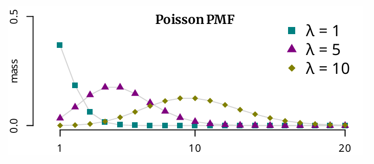

## Poisson Distribution(2)

We generally expect that the expectation, i.e. the mean $\lambda = \mathbb{E}[y]$, depends on other variables. Consider a **Poisson model** with a dependent mean; let

$$\lambda = \mathbb{E}[y \mid X; \beta] = \exp(X\beta),$$

where we use the exponential function to ensure that $\mathbb{E}[y \mid X] > 0$. We obtain

$$\mathbb{P}(Y = y_i \mid x_i; \beta) =
\frac{\exp(x_i \beta)^{\,y_i} \, \exp\!\left(-\exp(x_i \beta)\right)}
{y_i!},$$

describing the probability of each observation.

# Reference

Cunningham, S. (2021). *Causal inference*. Yale University Press. https://doi.org/10.12987/9780300255881